# Lung and Bronchus Cancer Regression Analysis

12/11/2020

Authors: “Alex Boutilier,Daniel Perry, and Calum Shea”

Abstract:

Lung and bronchus cancer are deadly cancers that target the cardiovascular system in the human body. In the United States, lung and bronchus cancer has only a 20.5% 5-year survival rate, it makes up 22.4% of all cancer deaths, and is the second most common type of cancer. We perform a regression analysis of lung and bronchus cancer rates (age-adjusted) in the United States. Our goal here is to find significant predictors that would increase/decrease lung and bronchus cancer rates, so we may have a better understanding of where to focus our resources in fighting this disease.

Source: https://seer.cancer.gov/statfacts/html/lungb.html

Introduction:

Regression analysis conducted to determine the most contributing factors to incidences of Lung and Bronchus cancer in the United States. We look at a variety of factors from different categories such as education, diet, smoking, and economic, using 2018 state-level data. Rather than developing a prediction model we are more so interested in the relationship between these variables and the incidence rate. If a given relationship proves to be strong and consistent across states then we can reasonably conclude that particular variable is a significant factor that it would be justified in directing policy towards at a country level given it is immune to changes across states. Reducing the incident rate of lung and bronchus cancer is desirable because the unprecedented amount of death, emotional damage, and financial cost that this disease burdens the US with.

Import master data sheet

All data is categorized by state.

Data Description:

Incidence Data sourced from https://statecancerprofiles.cancer.gov/incidencerates/index.php

Definitions:

Total_Population: the population by state

Incidence_Rate: the incidence rate of lung and bronchus cancer Age-Adjusted cases per 100,000

Lower_95._Confidence_Interval and Upper_95._Confidence_Interval: the CI bounds for the incidence rate of lung and bronchus cancer

Average_Annual_Count: the average annual count of lung and bronchus cancer by state

Recent_Trend: the incidence rate trend

Recent_5_Year.Trend_in_Incidence_Rates: the change in incidence rate of lung and bronchus cancer in the past 5 years

Screening and Risk Factors Data sourced from https://statecancerprofiles.cancer.gov/risk/index.php

Num_Respondents: for each risk factor refers to the number of people responding to the survey

Current_Percentage_Smoke: the percentage of people who currently smoke answering the survey

Percent_No_One_Allowed_Smoking_at_Home: the percentage of people where smoking is not allowed at home

Percent_Ever_Smoked_100_Cigarettes: the percentage of people who have smoked over 100 cigarettes in their life

Percent_Workers_in_NonSmoking_Environment: the percentage of workers where smoking is prohibited in their workplace

Percent_Obese: the percentage of people aged 20+ that have a BMI that is greater or equal to 30

Percent_Healthy_Weight: the percentage of people aged 20+ with a BMI between 18.5 and 25

Percent_No_Physical_Activity: the percentage of people who engaged in no leisure-time physical activity

Percent_Consumed_More_Than_1Fruit_PerDay: the percentage of people who consumed more than 1 fruit per day

Percent_Consumed_More_Than_1Vegetable_PerDay: the percentage of people who consumed more than 1 vegetable per day

Demographics sourced from https://data.world/uscensusbureau/2014-american-community-survey and https://statecancerprofiles.cancer.gov/demographics/index.php

Disclaimer: We have converted certain population totals to percentages because the Incidence_Rate is per 100,000

All_Below_Poverty: total population below the poverty line

M_Below_Poverty: total male population below the poverty line

F_Below_Poverty: total female population below the poverty line

All_Above_Poverty: total population above the poverty line

M_Above_Poverty: total male population above the poverty line

F_Above_Poverty: total female population above the poverty line

Med_Income: the median income of the entire population

Med_Income_White: the median income of the white population

Med_Income_Black: the median income of the black population

Med_Income_Nat_Am: the median income of the national american population

Med_Income_Asian: the median income of the asian population

Med_Income_Hispanic: the median income of the hispanic population

M_With_HC: male population with health care

M_Wihtout_HC: male population without healthcare

F_With_HC: female population with health care

F_Wihtout_HC: female population without healthcare

All_With_HC: total population with healthcare

All_Without_HC: total population without healthcare

Percent_Without_HC: the percentage of population without healthcare

Percent_At_Least_Grad_Highschool: the percentage of people that have at least graduated high school

Percent_At_Least_Bachelors_Degree: the percentage of people that have completed at least a bachelors degree.

Unique Data Point:

We added a unique data point (as instructed) labeled “New State”. New State’s values are simply comprised of the averages of the variables in the real data. We chose this approach to mitigate the influence that an artificial data point would have on our analysis, because it is not representative of real world data, and would therefore not enhance our understanding of the real world data.

Methods:

In this study, we tested multiple independent variables to see how they relate to incidence rates of lung and bronchus cancers in the United States.

Research Data

Our data contains many variables such as smoking, obesity, and fruit and vegetable consumption that have been divided into further sub-variables (for example; smoking one hundred cigarettes in their life, allowed smoking in their house, and more). The data had been found within each state of the United States of America and certain population totals had been converted to percentages to avoid miscalculations when it came to measuring the incidence rate(per 100,000 citizens), so that everything would be scaled.

Data Analysis

For analyzing the data, we modeled all the data and removed the unwanted variables from our base model. We then did a Visual Exploratory Analysis where we investigated groups of predictors for possible correlation between them. After eliminating variables that were correlated with one or more others, we created a model with all relevant variables with no major signs or correlation.

Checking for multicollinearity was our next step. We do this by analyzing the variance inflation factors (VIFs) of each variable in our base model and eliminating the one with the largest value. After this, we repeat the process until all remaining variables have VIFs of less than seven (7).

After finding our new model, we had to validate it. We did this by observing the coefficients in our model, compared the VIFs from our original model to the new one, and made sure the predicted responses of the response variable were not the wrong sign. The data also had to have its root-mean-square-error (RMSE) evaluated, along with its prediction accuracy. This was performed by splitting the data in two sets (training and testing).

The next process was a residual analysis. To do this, we assessed the normality by making a Q-Q plot, assessed constant variance by plotting the residuals against fitted values and regressors (two separate plots), and removed states that were deemed to be outliers from both the Q-Q plot and residuals against fitted values. When this was done, we then examined the leverage points and influential observations by plotting residuals against leverage, and Cook’s Distance versus observation. This led us to see what the highly influential point(s) were and should be removed; and thus, our conclusions could be found regarding our main objective in this analysis.

Results:

Lets have a look at a histogram of the Incidence Rate so we understand the range/frequency.

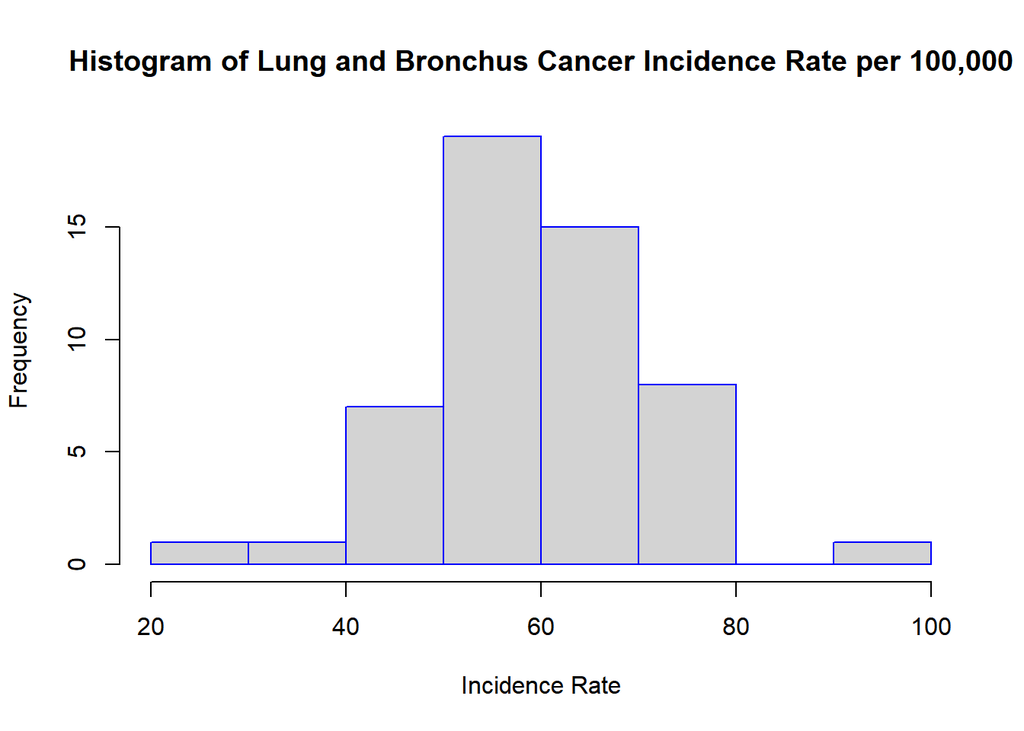

Model Selection:

assigning variables

```r
response = dataset[,4] #Y variable
predictors = dataset[,10:59]
```

delete unwanted variables from predictors for the base model

```r
predictors[,c(2,4,6,8,10,12,14,16,18,19,20,21,23,24,25,27,28,29,30,31,32,33,34,35,36,37,40,42,43,44,45,47,48,49)] = NULL
```

Visual Exploratory Analysis:

Checking groups of predictors that are likely to be correlated to each other

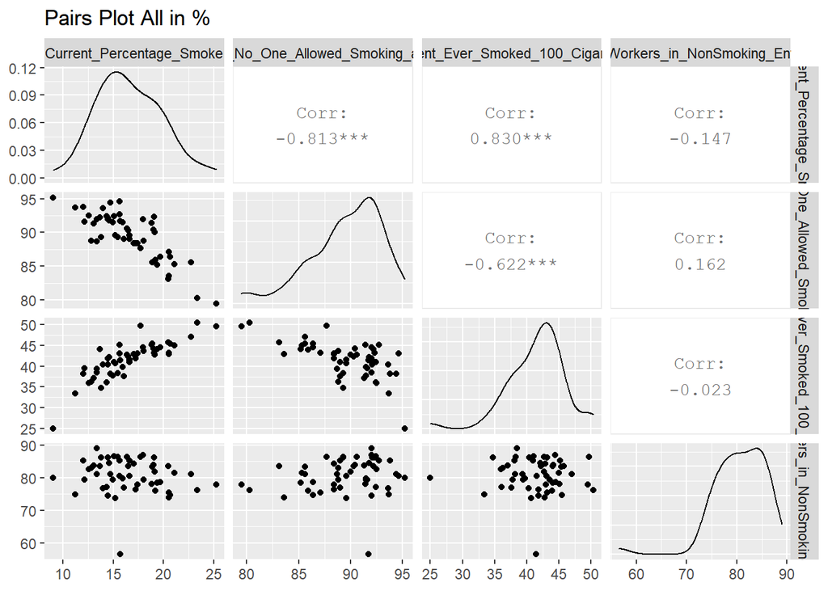

```r
smokingpredictors = predictors[,c(1,2,3,4)]
ggpairs(smokingpredictors,title = "Pairs Plot All in %")
```

Current_Percentage_Smoke is highly correlated with both No_One_Allowed_Smoking_at_Home and Ever_Smoked_100_Cigarretes.Therefore lets omit Current_Percentage_Smoke from our predictors.

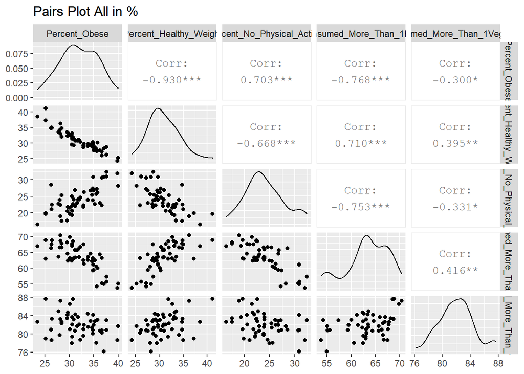

```r
predictors[,c(1)]=NULL

healthpredictors = predictors[,c(4,5,6,7,8)]
ggpairs(healthpredictors,title = "Pairs Plot All in %")
```

Percent_Obese and Percent_Healthy_Weight are highly correlated.

Therefore lets remove Percent_Healthy_Weight from the predictors.

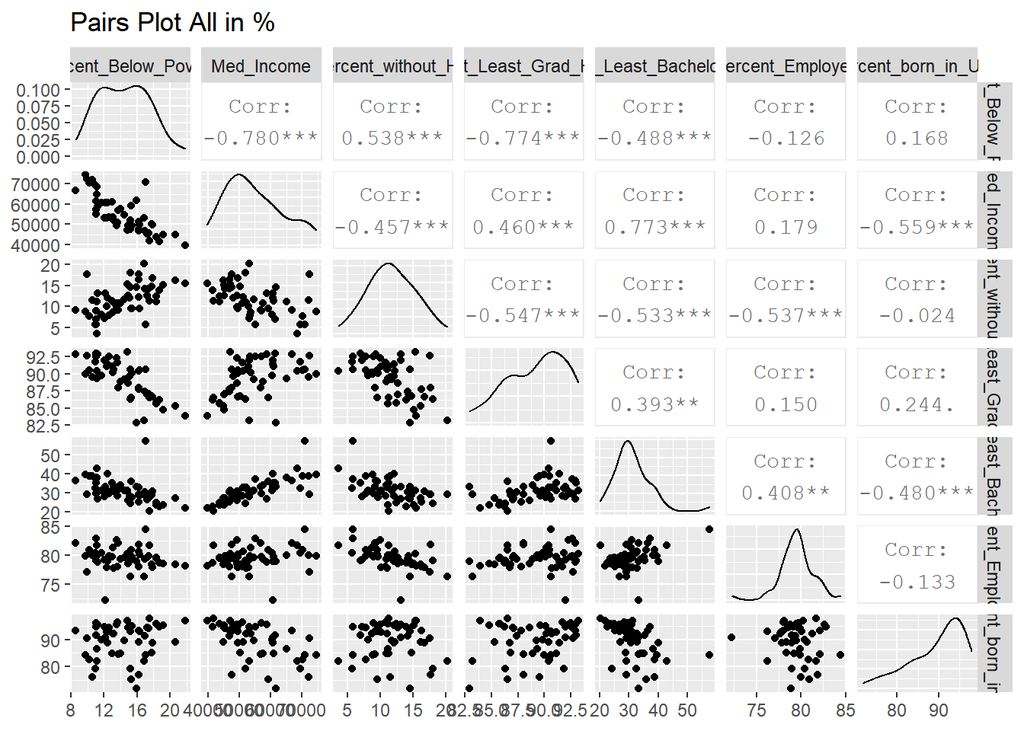

```r
predictors[,c(5)]=NULL

economicpredictors = predictors[,c(8,9,10,11,12,13,14)]

ggpairs(economicpredictors,title = "Pairs Plot All in %")
```

Here is the base model that includes all relevant variables:

```r
lungmodel = lm(Incidence_Rate ~ Percent_No_One_Allowed_Smoking_at_Home + Percent_Ever_Smoked_100_Cigarettes + Percent_Workers_in_NonSmoking_Environment
               + Percent_Obese + Percent_No_Physical_Activity + Percent_Consumed_More_Than_1Fruit_PerDay + Percent_Consumed_More_Than_1Vegetable_PerDay
               + Percent_Below_Poverty + Med_Income + Percent_without_HC + Percent_At_Least_Grad_Highschool + Percent_At_Least_Bachelors_Degree + Percent_Employed + Percent_born_in_USA, data = dataset)

summary(lungmodel)
```

```
##
## Call:
## lm(formula = Incidence_Rate ~ Percent_No_One_Allowed_Smoking_at_Home +
##     Percent_Ever_Smoked_100_Cigarettes + Percent_Workers_in_NonSmoking_Environment +
##     Percent_Obese + Percent_No_Physical_Activity + Percent_Consumed_More_Than_1Fruit_PerDay +
##     Percent_Consumed_More_Than_1Vegetable_PerDay + Percent_Below_Poverty +
##     Med_Income + Percent_without_HC + Percent_At_Least_Grad_Highschool +
##     Percent_At_Least_Bachelors_Degree + Percent_Employed + Percent_born_in_USA,
##     data = dataset)
##
## Residuals:
##      Min       1Q   Median       3Q      Max
## -11.3397  -1.4914   0.0515   2.4249   6.7495
##
## Coefficients:
##                                                Estimate Std. Error t value
## (Intercept)                                   2.979e+01  1.009e+02   0.295
## Percent_No_One_Allowed_Smoking_at_Home       -6.196e-01  4.142e-01  -1.496
## Percent_Ever_Smoked_100_Cigarettes            1.110e+00  4.132e-01   2.687
## Percent_Workers_in_NonSmoking_Environment     4.668e-01  1.825e-01   2.557
## Percent_Obese                                 1.068e+00  3.847e-01   2.775
## Percent_No_Physical_Activity                  1.330e+00  3.450e-01   3.855
## Percent_Consumed_More_Than_1Fruit_PerDay      4.611e-01  4.067e-01   1.134
## Percent_Consumed_More_Than_1Vegetable_PerDay  9.611e-01  4.860e-01   1.978
## Percent_Below_Poverty                        -9.903e-01  7.166e-01  -1.382
## Med_Income                                   -1.613e-04  2.431e-04  -0.663
## Percent_without_HC                           -2.892e-01  3.725e-01  -0.776
## Percent_At_Least_Grad_Highschool             -1.110e+00  6.724e-01  -1.651
## Percent_At_Least_Bachelors_Degree             9.084e-02  3.343e-01   0.272
## Percent_Employed                             -2.262e-01  8.078e-01  -0.280
## Percent_born_in_USA                          -3.552e-01  2.980e-01  -1.192
##                                              Pr(>|t|)
## (Intercept)                                  0.769560
## Percent_No_One_Allowed_Smoking_at_Home       0.143177
## Percent_Ever_Smoked_100_Cigarettes           0.010740 *
## Percent_Workers_in_NonSmoking_Environment    0.014782 *
## Percent_Obese                                0.008602 **
## Percent_No_Physical_Activity                 0.000445 ***
## Percent_Consumed_More_Than_1Fruit_PerDay     0.264123
## Percent_Consumed_More_Than_1Vegetable_PerDay 0.055454 .
## Percent_Below_Poverty                        0.175317
## Med_Income                                   0.511165
## Percent_without_HC                           0.442456
## Percent_At_Least_Grad_Highschool             0.107110
## Percent_At_Least_Bachelors_Degree            0.787318
## Percent_Employed                             0.781060
## Percent_born_in_USA                          0.240842
## ---
## Signif. codes:  0 '***' 0.001 '**' 0.01 '*' 0.05 '.' 0.1 ' ' 1
##
## Residual standard error: 4.544 on 37 degrees of freedom
## Multiple R-squared:  0.8851, Adjusted R-squared:  0.8417
## F-statistic: 20.37 on 14 and 37 DF,  p-value: 3.18e-13
```

After fitting a least squares model with the predictors regressed on Incidence_Rate response variable, we have a well-performing model base model, shown by the Adjusted R^2 of 0.8417.

Checking for Multicollinearity:

Checking the VIF’s allows us to assess the degree to which that independent variable is orthogonal the others.

```r
vif(lungmodel)
```

```
##       Percent_No_One_Allowed_Smoking_at_Home
##                                     5.135074
##           Percent_Ever_Smoked_100_Cigarettes
##                                     8.056411
##    Percent_Workers_in_NonSmoking_Environment
##                                     2.327472
##                                Percent_Obese
##                                     5.506598
##                 Percent_No_Physical_Activity
##                                     4.296286
##     Percent_Consumed_More_Than_1Fruit_PerDay
##                                     7.524650
## Percent_Consumed_More_Than_1Vegetable_PerDay
##                                     3.553156
##                        Percent_Below_Poverty
##                                    11.835358
##                                   Med_Income
##                                    11.998201
##                           Percent_without_HC
##                                     4.430785
##             Percent_At_Least_Grad_Highschool
##                                     8.623360
##            Percent_At_Least_Bachelors_Degree
##                                    10.849784
##                             Percent_Employed
##                                     5.946882
##                          Percent_born_in_USA
##                                     9.433523
```

Med_Income has the largest VIF of 11.998, lets remove it

```
##
## Call:
## lm(formula = Incidence_Rate ~ Percent_No_One_Allowed_Smoking_at_Home +
##     Percent_Ever_Smoked_100_Cigarettes + Percent_Workers_in_NonSmoking_Environment +
##     Percent_Obese + Percent_No_Physical_Activity + Percent_Consumed_More_Than_1Fruit_PerDay +
##     Percent_Consumed_More_Than_1Vegetable_PerDay + Percent_Below_Poverty +
##     Percent_without_HC + Percent_At_Least_Grad_Highschool + Percent_At_Least_Bachelors_Degree +
##     Percent_Employed + Percent_born_in_USA, data = dataset)
##
## Residuals:
##      Min       1Q   Median       3Q      Max
## -11.8864  -1.9072   0.1363   2.6366   6.8247
##
## Coefficients:
##                                              Estimate Std. Error t value
## (Intercept)                                  -7.14304   83.57580  -0.085
## Percent_No_One_Allowed_Smoking_at_Home       -0.58099    0.40706  -1.427
## Percent_Ever_Smoked_100_Cigarettes            1.11581    0.41001   2.721
## Percent_Workers_in_NonSmoking_Environment     0.45449    0.18025   2.521
## Percent_Obese                                 1.11003    0.37655   2.948
## Percent_No_Physical_Activity                  1.36077    0.33927   4.011
## Percent_Consumed_More_Than_1Fruit_PerDay      0.53811    0.38690   1.391
## Percent_Consumed_More_Than_1Vegetable_PerDay  1.03117    0.47084   2.190
## Percent_Below_Poverty                        -0.63487    0.47253  -1.344
## Percent_without_HC                           -0.31139    0.36823  -0.846
## Percent_At_Least_Grad_Highschool             -1.03180    0.65697  -1.571
## Percent_At_Least_Bachelors_Degree            -0.03431    0.27393  -0.125
## Percent_Employed                             -0.20692    0.80133  -0.258
## Percent_born_in_USA                          -0.31988    0.29103  -1.099
##                                              Pr(>|t|)
## (Intercept)                                  0.932338
## Percent_No_One_Allowed_Smoking_at_Home       0.161665
## Percent_Ever_Smoked_100_Cigarettes           0.009755 **
## Percent_Workers_in_NonSmoking_Environment    0.016001 *
## Percent_Obese                                0.005445 **
## Percent_No_Physical_Activity                 0.000273 ***
## Percent_Consumed_More_Than_1Fruit_PerDay     0.172365
## Percent_Consumed_More_Than_1Vegetable_PerDay 0.034728 *
## Percent_Below_Poverty                        0.187059
## Percent_without_HC                           0.403047
## Percent_At_Least_Grad_Highschool             0.124579
## Percent_At_Least_Bachelors_Degree            0.900995
## Percent_Employed                             0.797627
## Percent_born_in_USA                          0.278627
## ---
## Signif. codes:  0 '***' 0.001 '**' 0.01 '*' 0.05 '.' 0.1 ' ' 1
##
## Residual standard error: 4.51 on 38 degrees of freedom
## Multiple R-squared:  0.8838, Adjusted R-squared:  0.844
## F-statistic: 22.23 on 13 and 38 DF,  p-value: 8.074e-14
```

```
##       Percent_No_One_Allowed_Smoking_at_Home
##                                     5.033862
##           Percent_Ever_Smoked_100_Cigarettes
##                                     8.052913
##    Percent_Workers_in_NonSmoking_Environment
##                                     2.303413
##                                Percent_Obese
##                                     5.354394
##                 Percent_No_Physical_Activity
##                                     4.217987
##     Percent_Consumed_More_Than_1Fruit_PerDay
##                                     6.912235
## Percent_Consumed_More_Than_1Vegetable_PerDay
##                                     3.385217
##                        Percent_Below_Poverty
##                                     5.222556
##                           Percent_without_HC
##                                     4.395017
##             Percent_At_Least_Grad_Highschool
##                                     8.355540
##            Percent_At_Least_Bachelors_Degree
##                                     7.394649
##                             Percent_Employed
##                                     5.939215
##                          Percent_born_in_USA
##                                     9.132085
```

Percent_born_in_USA has a VIF of 9.132, lets remove it

```
##
## Call:
## lm(formula = Incidence_Rate ~ Percent_No_One_Allowed_Smoking_at_Home +
##     Percent_Ever_Smoked_100_Cigarettes + Percent_Workers_in_NonSmoking_Environment +
##     Percent_Obese + Percent_No_Physical_Activity + Percent_Consumed_More_Than_1Fruit_PerDay +
##     Percent_Consumed_More_Than_1Vegetable_PerDay + Percent_Below_Poverty +
##     Percent_without_HC + Percent_At_Least_Grad_Highschool + Percent_At_Least_Bachelors_Degree +
##     Percent_Employed, data = dataset)
##
## Residuals:
##      Min       1Q   Median       3Q      Max
## -12.2888  -2.0025   0.0458   2.3219   6.7282
##
## Coefficients:
##                                              Estimate Std. Error t value
## (Intercept)                                    7.6862    82.6993   0.093
## Percent_No_One_Allowed_Smoking_at_Home        -0.6713     0.3997  -1.679
## Percent_Ever_Smoked_100_Cigarettes             0.9580     0.3851   2.488
## Percent_Workers_in_NonSmoking_Environment      0.4118     0.1765   2.333
## Percent_Obese                                  0.8728     0.3094   2.821
## Percent_No_Physical_Activity                   1.3987     0.3384   4.133
## Percent_Consumed_More_Than_1Fruit_PerDay       0.6819     0.3651   1.868
## Percent_Consumed_More_Than_1Vegetable_PerDay   0.7428     0.3920   1.895
## Percent_Below_Poverty                         -0.8999     0.4075  -2.208
## Percent_without_HC                            -0.1699     0.3459  -0.491
## Percent_At_Least_Grad_Highschool              -1.3918     0.5710  -2.438
## Percent_At_Least_Bachelors_Degree             -0.0107     0.2738  -0.039
## Percent_Employed                               0.1623     0.7294   0.223
##                                              Pr(>|t|)
## (Intercept)                                  0.926426
## Percent_No_One_Allowed_Smoking_at_Home       0.101075
## Percent_Ever_Smoked_100_Cigarettes           0.017234 *
## Percent_Workers_in_NonSmoking_Environment    0.024881 *
## Percent_Obese                                0.007486 **
## Percent_No_Physical_Activity                 0.000183 ***
## Percent_Consumed_More_Than_1Fruit_PerDay     0.069313 .
## Percent_Consumed_More_Than_1Vegetable_PerDay 0.065541 .
## Percent_Below_Poverty                        0.033157 *
## Percent_without_HC                           0.626027
## Percent_At_Least_Grad_Highschool             0.019449 *
## Percent_At_Least_Bachelors_Degree            0.969016
## Percent_Employed                             0.825043
## ---
## Signif. codes:  0 '***' 0.001 '**' 0.01 '*' 0.05 '.' 0.1 ' ' 1
##
## Residual standard error: 4.522 on 39 degrees of freedom
## Multiple R-squared:  0.8801, Adjusted R-squared:  0.8432
## F-statistic: 23.85 on 12 and 39 DF,  p-value: 2.841e-14
```

```
##       Percent_No_One_Allowed_Smoking_at_Home
##                                     4.828704
##           Percent_Ever_Smoked_100_Cigarettes
##                                     7.065567
##    Percent_Workers_in_NonSmoking_Environment
##                                     2.196371
##                                Percent_Obese
##                                     3.594703
##                 Percent_No_Physical_Activity
##                                     4.174225
##     Percent_Consumed_More_Than_1Fruit_PerDay
##                                     6.121927
## Percent_Consumed_More_Than_1Vegetable_PerDay
##                                     2.333813
##                        Percent_Below_Poverty
##                                     3.862820
##                           Percent_without_HC
##                                     3.858056
##             Percent_At_Least_Grad_Highschool
##                                     6.278357
##            Percent_At_Least_Bachelors_Degree
##                                     7.349207
##                             Percent_Employed
##                                     4.895258
```

Percent_At_Least_Bachelors_Degree has a VIF of 7.349, lets remove it

```
##
## Call:
## lm(formula = Incidence_Rate ~ Percent_No_One_Allowed_Smoking_at_Home +
##     Percent_Ever_Smoked_100_Cigarettes + Percent_Workers_in_NonSmoking_Environment +
##     Percent_Obese + Percent_No_Physical_Activity + Percent_Consumed_More_Than_1Fruit_PerDay +
##     Percent_Consumed_More_Than_1Vegetable_PerDay + Percent_Below_Poverty +
##     Percent_without_HC + Percent_At_Least_Grad_Highschool + Percent_Employed,
##     data = dataset)
##
## Residuals:
##      Min       1Q   Median       3Q      Max
## -12.2955  -2.0220   0.0372   2.3418   6.7478
##
## Coefficients:
##                                              Estimate Std. Error t value
## (Intercept)                                    8.5223    78.8822   0.108
## Percent_No_One_Allowed_Smoking_at_Home        -0.6702     0.3937  -1.702
## Percent_Ever_Smoked_100_Cigarettes             0.9685     0.2723   3.557
## Percent_Workers_in_NonSmoking_Environment      0.4099     0.1673   2.450
## Percent_Obese                                  0.8756     0.2969   2.949
## Percent_No_Physical_Activity                   1.3999     0.3329   4.205
## Percent_Consumed_More_Than_1Fruit_PerDay       0.6829     0.3596   1.899
## Percent_Consumed_More_Than_1Vegetable_PerDay   0.7363     0.3506   2.100
## Percent_Below_Poverty                         -0.8982     0.4000  -2.245
## Percent_without_HC                            -0.1691     0.3410  -0.496
## Percent_At_Least_Grad_Highschool              -1.3913     0.5636  -2.468
## Percent_Employed                               0.1461     0.5925   0.247
##                                              Pr(>|t|)
## (Intercept)                                  0.914505
## Percent_No_One_Allowed_Smoking_at_Home       0.096435 .
## Percent_Ever_Smoked_100_Cigarettes           0.000984 ***
## Percent_Workers_in_NonSmoking_Environment    0.018765 *
## Percent_Obese                                0.005299 **
## Percent_No_Physical_Activity                 0.000143 ***
## Percent_Consumed_More_Than_1Fruit_PerDay     0.064755 .
## Percent_Consumed_More_Than_1Vegetable_PerDay 0.042069 *
## Percent_Below_Poverty                        0.030344 *
## Percent_without_HC                           0.622608
## Percent_At_Least_Grad_Highschool             0.017946 *
## Percent_Employed                             0.806458
## ---
## Signif. codes:  0 '***' 0.001 '**' 0.01 '*' 0.05 '.' 0.1 ' ' 1
##
## Residual standard error: 4.465 on 40 degrees of freedom
## Multiple R-squared:  0.8801, Adjusted R-squared:  0.8471
## F-statistic: 26.68 on 11 and 40 DF,  p-value: 5.325e-15
```

```
##       Percent_No_One_Allowed_Smoking_at_Home
##                                     4.802599
##           Percent_Ever_Smoked_100_Cigarettes
##                                     3.623850
##    Percent_Workers_in_NonSmoking_Environment
##                                     2.024293
##                                Percent_Obese
##                                     3.395581
##                 Percent_No_Physical_Activity
##                                     4.143836
##     Percent_Consumed_More_Than_1Fruit_PerDay
##                                     6.090599
## Percent_Consumed_More_Than_1Vegetable_PerDay
##                                     1.914609
##                        Percent_Below_Poverty
##                                     3.818230
##                           Percent_without_HC
##                                     3.845067
##             Percent_At_Least_Grad_Highschool
##                                     6.274208
##                             Percent_Employed
##                                     3.312409
```

The remaining VIF’s are below 7 and we will move forward with finding the “best” model with stepwise in backwards direction.

```
## Start:  AIC=165.98
## Incidence_Rate ~ Percent_No_One_Allowed_Smoking_at_Home + Percent_Ever_Smoked_100_Cigarettes +
##     Percent_Workers_in_NonSmoking_Environment + Percent_Obese +
##     Percent_No_Physical_Activity + Percent_Consumed_More_Than_1Fruit_PerDay +
##     Percent_Consumed_More_Than_1Vegetable_PerDay + Percent_Below_Poverty +
##     Percent_without_HC + Percent_At_Least_Grad_Highschool + Percent_Employed
##
##                                                Df Sum of Sq     RSS    AIC
## - Percent_Employed                              1      1.21  798.79 164.06
## - Percent_without_HC                            1      4.91  802.48 164.30
## <none>                                                       797.57 165.98
## - Percent_No_One_Allowed_Smoking_at_Home        1     57.79  855.36 167.62
## - Percent_Consumed_More_Than_1Fruit_PerDay      1     71.93  869.50 168.47
## - Percent_Consumed_More_Than_1Vegetable_PerDay  1     87.94  885.52 169.42
## - Percent_Below_Poverty                         1    100.52  898.09 170.15
## - Percent_Workers_in_NonSmoking_Environment     1    119.67  917.24 171.25
## - Percent_At_Least_Grad_Highschool              1    121.48  919.06 171.35
## - Percent_Obese                                 1    173.44  971.01 174.21
## - Percent_Ever_Smoked_100_Cigarettes            1    252.22 1049.79 178.26
## - Percent_No_Physical_Activity                  1    352.52 1150.09 183.01
##
## Step:  AIC=164.06
## Incidence_Rate ~ Percent_No_One_Allowed_Smoking_at_Home + Percent_Ever_Smoked_100_Cigarettes +
##     Percent_Workers_in_NonSmoking_Environment + Percent_Obese +
##     Percent_No_Physical_Activity + Percent_Consumed_More_Than_1Fruit_PerDay +
##     Percent_Consumed_More_Than_1Vegetable_PerDay + Percent_Below_Poverty +
##     Percent_without_HC + Percent_At_Least_Grad_Highschool
##
##                                                Df Sum of Sq     RSS    AIC
## - Percent_without_HC                            1      9.76  808.54 162.69
## <none>                                                       798.79 164.06
## - Percent_No_One_Allowed_Smoking_at_Home        1     57.58  856.37 165.68
## - Percent_Consumed_More_Than_1Fruit_PerDay      1     86.55  885.33 167.41
## - Percent_Consumed_More_Than_1Vegetable_PerDay  1     95.98  894.77 167.96
## - Percent_Below_Poverty                         1     99.49  898.27 168.16
## - Percent_Workers_in_NonSmoking_Environment     1    119.31  918.09 169.29
## - Percent_At_Least_Grad_Highschool              1    145.68  944.46 170.77
## - Percent_Obese                                 1    185.15  983.94 172.90
## - Percent_No_Physical_Activity                  1    365.76 1164.55 181.66
## - Percent_Ever_Smoked_100_Cigarettes            1    424.02 1222.80 184.20
##
## Step:  AIC=162.69
## Incidence_Rate ~ Percent_No_One_Allowed_Smoking_at_Home + Percent_Ever_Smoked_100_Cigarettes +
##     Percent_Workers_in_NonSmoking_Environment + Percent_Obese +
##     Percent_No_Physical_Activity + Percent_Consumed_More_Than_1Fruit_PerDay +
##     Percent_Consumed_More_Than_1Vegetable_PerDay + Percent_Below_Poverty +
##     Percent_At_Least_Grad_Highschool
##
##                                                Df Sum of Sq     RSS    AIC
## <none>                                                       808.54 162.69
## - Percent_Consumed_More_Than_1Vegetable_PerDay  1     95.39  903.93 166.49
## - Percent_Below_Poverty                         1    127.03  935.57 168.28
## - Percent_No_One_Allowed_Smoking_at_Home        1    129.93  938.47 168.44
## - Percent_At_Least_Grad_Highschool              1    140.01  948.55 168.99
## - Percent_Consumed_More_Than_1Fruit_PerDay      1    146.60  955.14 169.35
## - Percent_Workers_in_NonSmoking_Environment     1    146.90  955.44 169.37
## - Percent_Obese                                 1    187.45  995.99 171.53
## - Percent_No_Physical_Activity                  1    372.68 1181.23 180.40
## - Percent_Ever_Smoked_100_Cigarettes            1    414.37 1222.91 182.20
```

```
##
## Call:
## lm(formula = Incidence_Rate ~ Percent_No_One_Allowed_Smoking_at_Home +
##     Percent_Ever_Smoked_100_Cigarettes + Percent_Workers_in_NonSmoking_Environment +
##     Percent_Obese + Percent_No_Physical_Activity + Percent_Consumed_More_Than_1Fruit_PerDay +
##     Percent_Consumed_More_Than_1Vegetable_PerDay + Percent_Below_Poverty +
##     Percent_At_Least_Grad_Highschool, data = dataset)
##
## Residuals:
##      Min       1Q   Median       3Q      Max
## -12.3899  -1.9733   0.2417   2.3544   6.7697
##
## Coefficients:
##                                              Estimate Std. Error t value
## (Intercept)                                   21.3231    61.8881   0.345
## Percent_No_One_Allowed_Smoking_at_Home        -0.8258     0.3179  -2.598
## Percent_Ever_Smoked_100_Cigarettes             0.9829     0.2119   4.639
## Percent_Workers_in_NonSmoking_Environment      0.4390     0.1589   2.762
## Percent_Obese                                  0.8557     0.2742   3.120
## Percent_No_Physical_Activity                   1.4230     0.3234   4.400
## Percent_Consumed_More_Than_1Fruit_PerDay       0.8210     0.2975   2.760
## Percent_Consumed_More_Than_1Vegetable_PerDay   0.7512     0.3375   2.226
## Percent_Below_Poverty                         -0.9684     0.3770  -2.569
## Percent_At_Least_Grad_Highschool              -1.4031     0.5203  -2.697
##                                              Pr(>|t|)
## (Intercept)                                   0.73216
## Percent_No_One_Allowed_Smoking_at_Home        0.01288 *
## Percent_Ever_Smoked_100_Cigarettes           3.40e-05 ***
## Percent_Workers_in_NonSmoking_Environment     0.00848 **
## Percent_Obese                                 0.00326 **
## Percent_No_Physical_Activity                 7.27e-05 ***
## Percent_Consumed_More_Than_1Fruit_PerDay      0.00854 **
## Percent_Consumed_More_Than_1Vegetable_PerDay  0.03144 *
## Percent_Below_Poverty                         0.01385 *
## Percent_At_Least_Grad_Highschool              0.01003 *
## ---
## Signif. codes:  0 '***' 0.001 '**' 0.01 '*' 0.05 '.' 0.1 ' ' 1
##
## Residual standard error: 4.388 on 42 degrees of freedom
## Multiple R-squared:  0.8784, Adjusted R-squared:  0.8524
## F-statistic: 33.72 on 9 and 42 DF,  p-value: < 2.2e-16
```

```
##       Percent_No_One_Allowed_Smoking_at_Home
##                                     3.243063
##           Percent_Ever_Smoked_100_Cigarettes
##                                     2.271980
##    Percent_Workers_in_NonSmoking_Environment
##                                     1.892101
##                                Percent_Obese
##                                     3.000374
##                 Percent_No_Physical_Activity
##                                     4.050379
##     Percent_Consumed_More_Than_1Fruit_PerDay
##                                     4.318363
## Percent_Consumed_More_Than_1Vegetable_PerDay
##                                     1.837617
##                        Percent_Below_Poverty
##                                     3.512260
##             Percent_At_Least_Grad_Highschool
##                                     5.537389
```

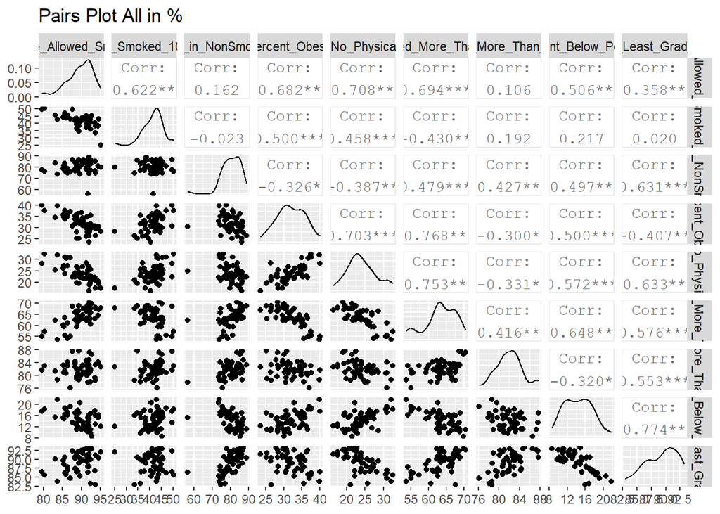

Percent_At_Least_Grad_Highschool has a VIF above 5, lets remove it

```
##
## Call:
## lm(formula = Incidence_Rate ~ Percent_No_One_Allowed_Smoking_at_Home +
##     Percent_Ever_Smoked_100_Cigarettes + Percent_Workers_in_NonSmoking_Environment +
##     Percent_Obese + Percent_No_Physical_Activity + Percent_Consumed_More_Than_1Fruit_PerDay +
##     Percent_Consumed_More_Than_1Vegetable_PerDay + Percent_Below_Poverty,
##     data = dataset)
##
## Residuals:
##      Min       1Q   Median       3Q      Max
## -13.1937  -2.6864   0.1024   3.2030   7.9817
##
## Coefficients:
##                                              Estimate Std. Error t value
## (Intercept)                                  -82.0680    52.0059  -1.578
## Percent_No_One_Allowed_Smoking_at_Home        -0.8300     0.3402  -2.439
## Percent_Ever_Smoked_100_Cigarettes             0.7964     0.2144   3.715
## Percent_Workers_in_NonSmoking_Environment      0.2845     0.1587   1.793
## Percent_Obese                                  0.7515     0.2906   2.586
## Percent_No_Physical_Activity                   1.8649     0.2985   6.248
## Percent_Consumed_More_Than_1Fruit_PerDay       0.9116     0.3164   2.881
## Percent_Consumed_More_Than_1Vegetable_PerDay   0.4599     0.3423   1.344
## Percent_Below_Poverty                         -0.3015     0.3046  -0.990
##                                              Pr(>|t|)
## (Intercept)                                  0.121883
## Percent_No_One_Allowed_Smoking_at_Home       0.018913 *
## Percent_Ever_Smoked_100_Cigarettes           0.000581 ***
## Percent_Workers_in_NonSmoking_Environment    0.080055 .
## Percent_Obese                                0.013184 *
## Percent_No_Physical_Activity                 1.59e-07 ***
## Percent_Consumed_More_Than_1Fruit_PerDay     0.006160 **
## Percent_Consumed_More_Than_1Vegetable_PerDay 0.186068
## Percent_Below_Poverty                        0.327730
## ---
## Signif. codes:  0 '***' 0.001 '**' 0.01 '*' 0.05 '.' 0.1 ' ' 1
##
## Residual standard error: 4.697 on 43 degrees of freedom
## Multiple R-squared:  0.8574, Adjusted R-squared:  0.8308
## F-statistic: 32.31 on 8 and 43 DF,  p-value: 9.104e-16
```

```
##       Percent_No_One_Allowed_Smoking_at_Home
##                                     3.242984
##           Percent_Ever_Smoked_100_Cigarettes
##                                     2.029827
##    Percent_Workers_in_NonSmoking_Environment
##                                     1.646074
##                                Percent_Obese
##                                     2.940817
##                 Percent_No_Physical_Activity
##                                     3.010800
##     Percent_Consumed_More_Than_1Fruit_PerDay
##                                     4.263224
## Percent_Consumed_More_Than_1Vegetable_PerDay
##                                     1.649354
##                        Percent_Below_Poverty
##                                     2.001175
```

From the VIF’s they indicate that the model is not likely affected by multicollinearity, however not all the parameters are statistically significant All the coefficients logically make sense except Consumed_More_Than_1Vegetable_PerDay which may have the wrong sign.

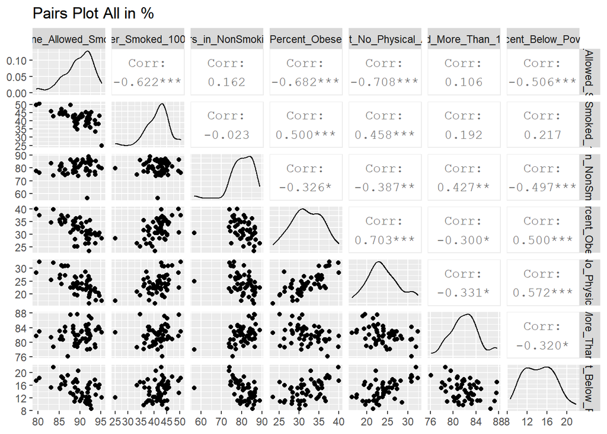

```r
Xfinal = predictors[,c(1,2,3,4,5,7,8)]
ggpairs(Xfinal,title = "Pairs Plot All in %")
```

The predictors of the final model do not look linearly dependent. We must choose to go with either the final model or the selected model. The “selectedModel” might have minor multicollinearity problems but all the coefficients are significant. The final model has less multicollinearity problems but not all the coefficients are statistically significant. We are moving forward with the selectedModel being our preferred model on the basis of its significant predictors and higher adjusted r-squared.

Validation of model:

1. Analysis of the Model Coefficients and Predicted Values

Are coefficients stable? Are signs and magnitudes reasonable?

```
##                                  (Intercept)
##                                   21.3231026
##       Percent_No_One_Allowed_Smoking_at_Home
##                                   -0.8257671
##           Percent_Ever_Smoked_100_Cigarettes
##                                    0.9829396
##    Percent_Workers_in_NonSmoking_Environment
##                                    0.4390185
##                                Percent_Obese
##                                    0.8556702
##                 Percent_No_Physical_Activity
##                                    1.4230416
##     Percent_Consumed_More_Than_1Fruit_PerDay
##                                    0.8209540
## Percent_Consumed_More_Than_1Vegetable_PerDay
##                                    0.7512156
##                        Percent_Below_Poverty
##                                   -0.9683846
##             Percent_At_Least_Grad_Highschool
##                                   -1.4031308
```

The coefficients Percent_Ever_Smoked_100_Cigarettes, Percent_Obese, Percent_No_One_Allowed_Smoking_at_Home, Percent_No_Physical_Activity all have signs that seem plausible, as well as reasonable magnitudes.The Percent_At_Least_Grad_Highschool coefficient has a negative magnitude that may be to large. Percent_Consumed_More_Than_1Fruit_PerDay’s coefficient and Percent_Consumed_More_Than_1Vegetable_PerDay’s coefficient are not reasonable.

Possible explanations of coefficients signs, why we aren’t necessarily concerned:

Percent at least graduated high school, percent below poverty, and percent workers in non-smoking environment, yield some coefficients that may go against our intuition, we did not determine any to be problematic as there are reasonable arguments to be made that would explain their effect. Percent at least graduated high school having a negative impact on the incidence rate is perfectly reasonable as more educated individuals may have a better understanding of the impact of smoking among many other explanations. Percent below poverty having a negative impact on the incident rate may simply be because those with less disposable income have less money to buy cigarettes with and as a result fewer of the poor develop lung and bronchus cancer. Working in a non-smoking environment having a positive effect on the cancer rate may be the least intuitive but having to abstain from smoking all day without relief may result in chain smoking outside of work.

2. Are VIFs or other measures of collinearity raising flags?

Now apply variance inflation factors to assess for multicollinearity. A large vif indicates that the variable is not linearly independent with the others. A large vif is typically a value exceeding 10.

```r
vif(lungmodel)
```

```
##       Percent_No_One_Allowed_Smoking_at_Home
##                                     5.135074
##           Percent_Ever_Smoked_100_Cigarettes
##                                     8.056411
##    Percent_Workers_in_NonSmoking_Environment
##                                     2.327472
##                                Percent_Obese
##                                     5.506598
##                 Percent_No_Physical_Activity
##                                     4.296286
##     Percent_Consumed_More_Than_1Fruit_PerDay
##                                     7.524650
## Percent_Consumed_More_Than_1Vegetable_PerDay
##                                     3.553156
##                        Percent_Below_Poverty
##                                    11.835358
##                                   Med_Income
##                                    11.998201
##                           Percent_without_HC
##                                     4.430785
##             Percent_At_Least_Grad_Highschool
##                                     8.623360
##            Percent_At_Least_Bachelors_Degree
##                                    10.849784
##                             Percent_Employed
##                                     5.946882
##                          Percent_born_in_USA
##                                     9.433523
```

From our original model we can see that several predictors have larger vif’s than 10 indicating that some of the predictors may have multicollinearity problems.

```r
vif(selectedModel)
```

```
##       Percent_No_One_Allowed_Smoking_at_Home
##                                     3.243063
##           Percent_Ever_Smoked_100_Cigarettes
##                                     2.271980
##    Percent_Workers_in_NonSmoking_Environment
##                                     1.892101
##                                Percent_Obese
##                                     3.000374
##                 Percent_No_Physical_Activity
##                                     4.050379
##     Percent_Consumed_More_Than_1Fruit_PerDay
##                                     4.318363
## Percent_Consumed_More_Than_1Vegetable_PerDay
##                                     1.837617
##                        Percent_Below_Poverty
##                                     3.512260
##             Percent_At_Least_Grad_Highschool
##                                     5.537389
```

However when we removed the predictors that were not significant via the stepwise regression method with backward elimination, all the vif’s are well below 10. Thus multicollinearity seems to be less of a problem with our new selected model.Our selected model seems to not be affected by multicollinearity in such a way that would undermine the integrity of the model and the parameters are all statistically significant.

Are predicted responses y of the wrong sign? Or outside of the range of those observed?

```
##     1     2     3     4     5     6     7     8     9    10    11    12    13
## 69.68 52.04 47.42 76.05 44.78 43.01 57.37 47.73 70.50 59.42 57.19 43.79 45.33
##    14    15    16    17    18    19    20    21    22    23    24    25    26
## 61.31 70.26 61.93 58.61 87.73 65.33 73.59 55.92 58.19 65.44 54.87 70.93 67.84
##    27    28    29    30    31    32    33    34    35    36    37    38    39
## 54.28 55.63 46.73 66.70 61.65 50.89 56.36 63.53 59.62 71.18 65.40 49.96 66.59
##    40    41    42    43    44    45    46    47    48    49    50    51    52
## 64.10 64.95 59.92 75.97 56.52 28.52 58.98 54.88 47.23 81.13 59.79 54.36 59.62
```

```
##  [1] 64.90 55.80 46.80 77.20 41.50 41.40 59.60 46.60 66.90 57.70 62.80 45.70
## [13] 49.50 63.70 72.20 63.30 56.20 91.00 66.20 72.10 56.40 61.20 63.30 56.10
## [25] 74.90 72.00 53.70 57.20 53.30 63.70 55.30 38.50 58.70 67.70 57.70 67.90
## [37] 67.40 54.10 63.50 70.30 64.40 59.00 74.50 50.60 26.00 61.10 56.40 54.00
## [49] 79.80 59.10 42.20 59.63
```

The predicted responses of Incidence_Rate from the selectedModel are all the correct sign and well within the range of those that were observed.

We will now split the data into training and testing sets to evaluate the RMSE and prediction accuracy

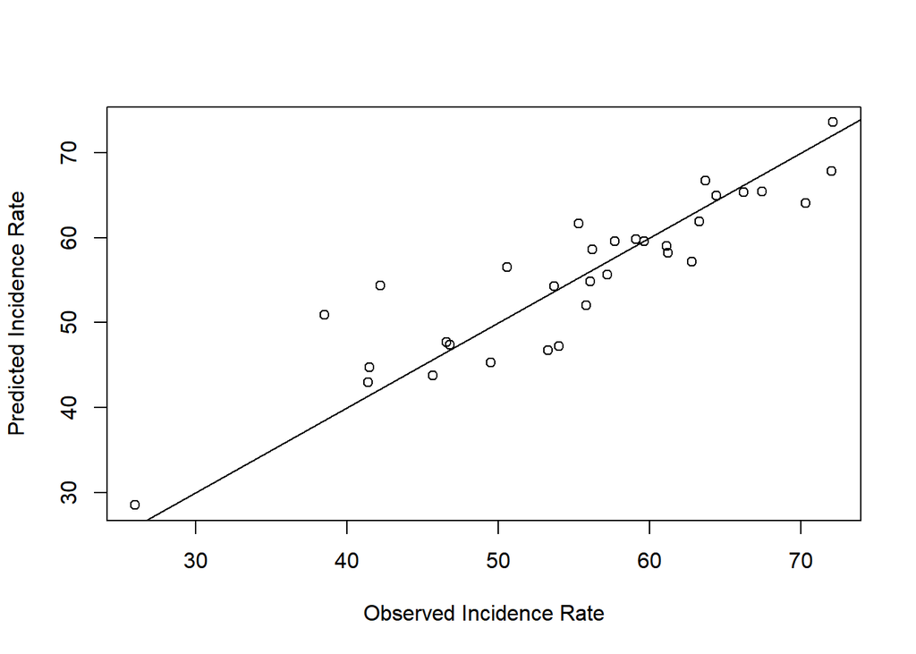

```
## [1] 1.000000 4.525359
```

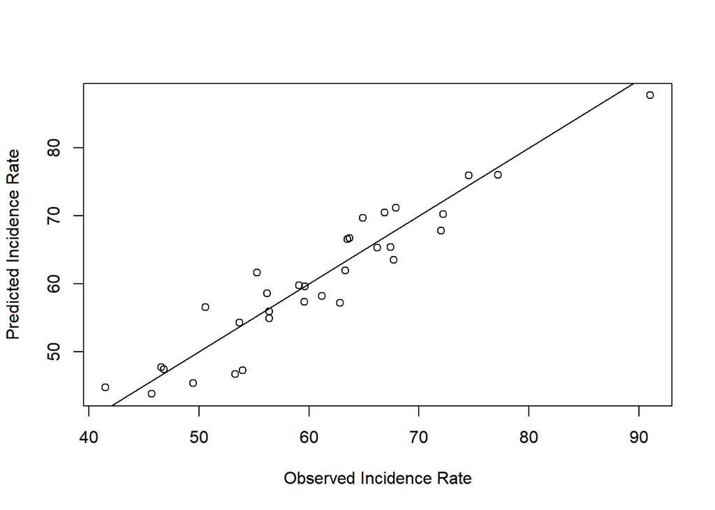

```
## [1] 2.000000 3.431079
```

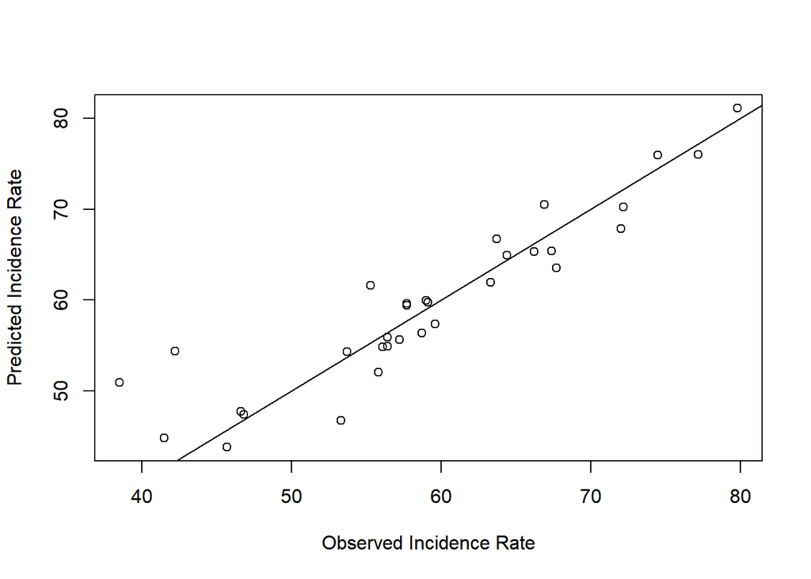

```
## [1] 3.000000 4.003684
```

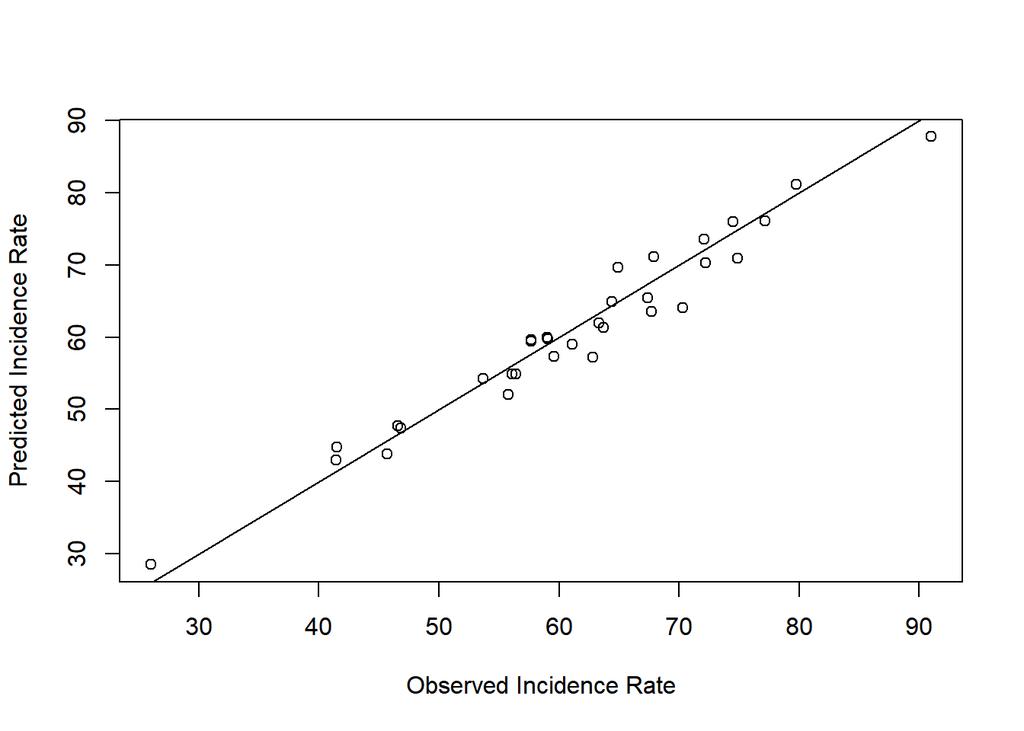

```
## [1] 4.000000 2.687879
```

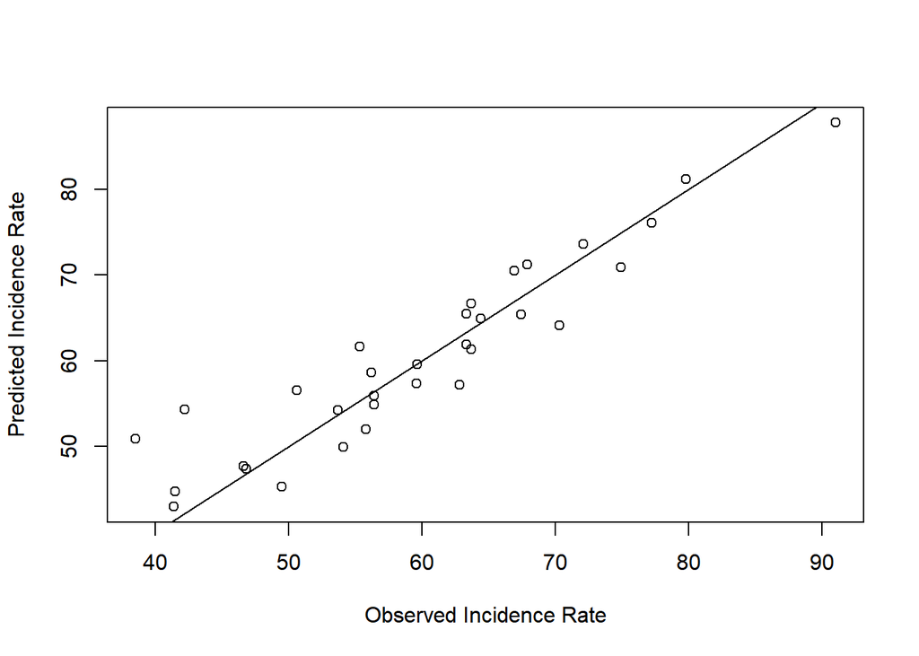

```
## [1] 5.000000 4.347251
```

```r
set.seed(1)

ratio=20

for(i in 1:5){

  train = sample(c(1:length(dataset$Incidence_Rate)),ratio)
  traindat = dataset[train, ]
  testdat = dataset[-train, ]

  trainmodel = lm(formula = Incidence_Rate ~ Percent_No_One_Allowed_Smoking_at_Home +
                   Percent_Ever_Smoked_100_Cigarettes + Percent_Workers_in_NonSmoking_Environment +
                   Percent_Obese + Percent_No_Physical_Activity + Percent_Consumed_More_Than_1Fruit_PerDay +
                   Percent_Consumed_More_Than_1Vegetable_PerDay + Percent_Below_Poverty+ Percent_At_Least_Grad_Highschool, data = traindat)
  summary(trainmodel)

  predic = predict(selectedModel,testdat)

  plot(testdat$Incidence_Rate,predic,xlab = "Observed Incidence Rate",ylab = "Predicted Incidence Rate")
  abline(c(0,1))

  RMSE = sqrt(sum((predic-testdat$Incidence_Rate)^2)/length(predic))


  print(c(i,RMSE))

}
```

Residual Analysis:

Assessing Normality:

To determine whether our residuals fulfill the assumption of being normally distributed we generated a “QQ Plot”. It appears that data points 32 (New Mexico), and 51 (Wyoming) are severe outliers in this test of normality and should therefore be considered for removal from the data if proved to be influential. Other than that, there is no other obvious departure from normality in this plot.

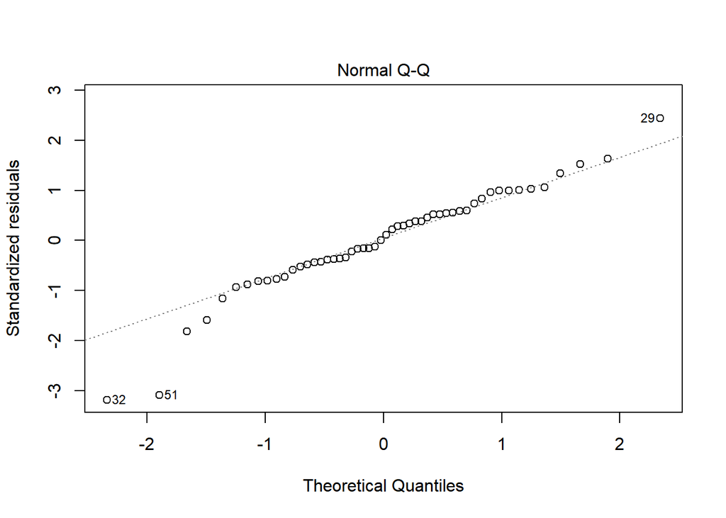

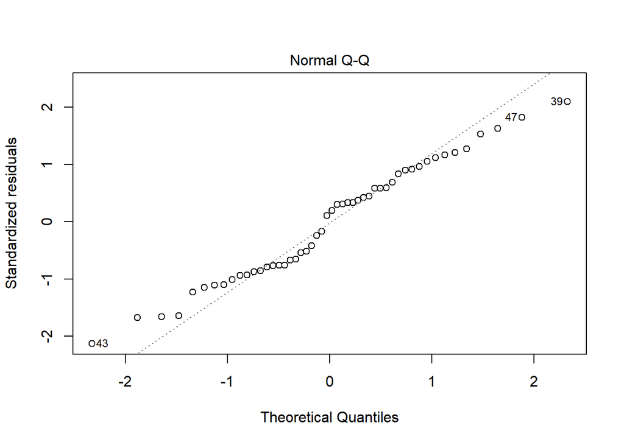

Assessing Constant Variance:

To determine whether our residuals fulfill the assumption of having constant variance, we generated a plot of the residuals against the fitted values from the model. Again data points 32 (New Mexico) and 51 (Wyoming) raise concern as they are the only severe outliers. Besides that, we see generally equal variance around the mean of zero.

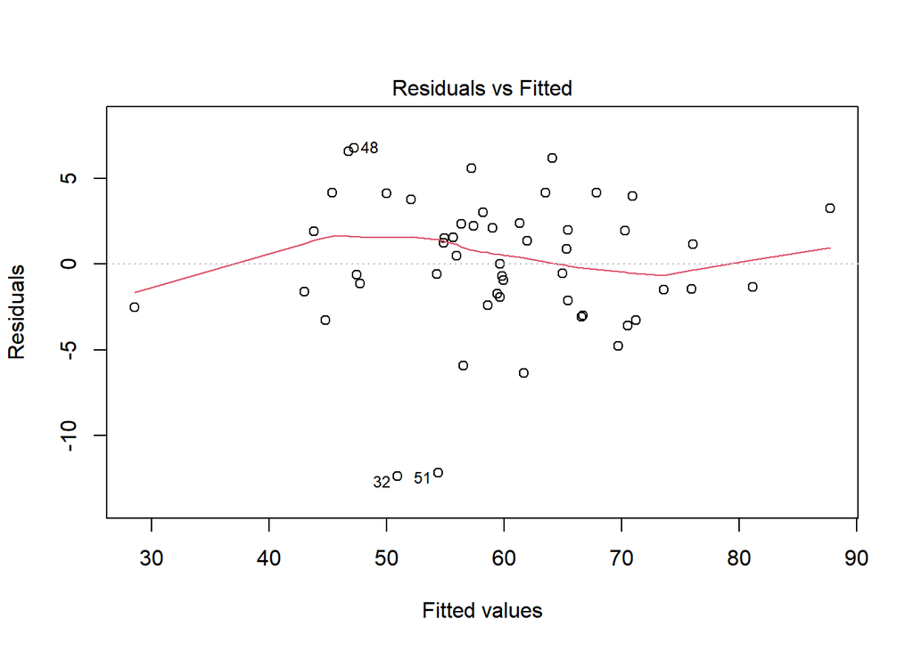

After removing 32 (New Mexico) and 51 (Wyoming), there are still several mild outliers but not nearly as severe. There is no obvious departure from our equal variance assumption here. Thus, we have satisfied this assumption.

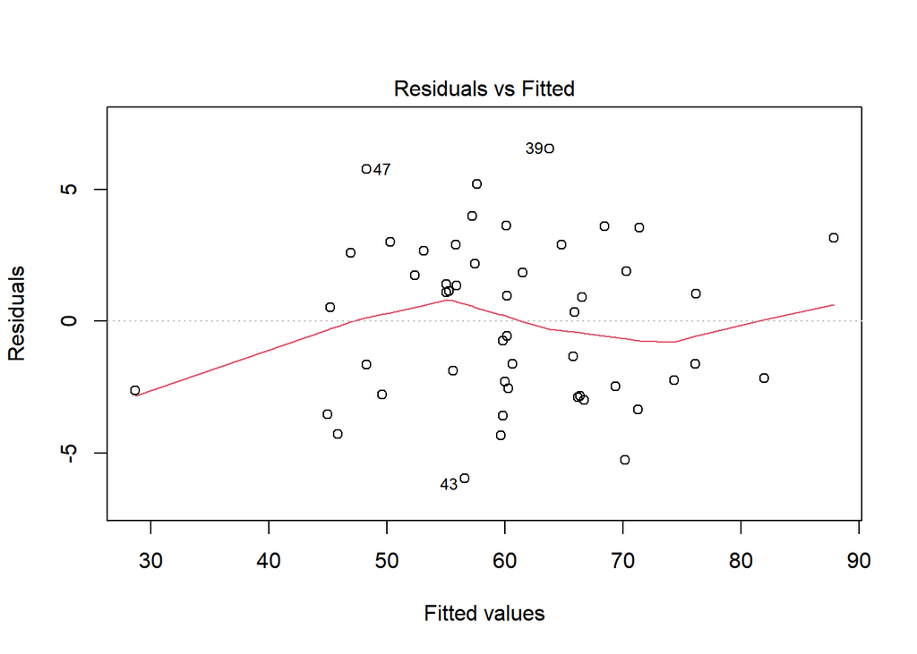

Plotting Residuals against Regressors:

Another check for constant variance. Plotting the residuals against our regressors will provide reassurance for our constant variance assumption that may not have been picked up in our residuals vs fitted values plot. We will also be able to make sure that there is not any type of unwanted relationship between the regressors and our error such as a quadratic or “funnel” pattern. The partial plots contain roughly equal variance and do not suggest there are any serious issues. Potentially influential observations are repeatedly showing up in our tests and will be assessed and considered for removal in the following section of our analysis.

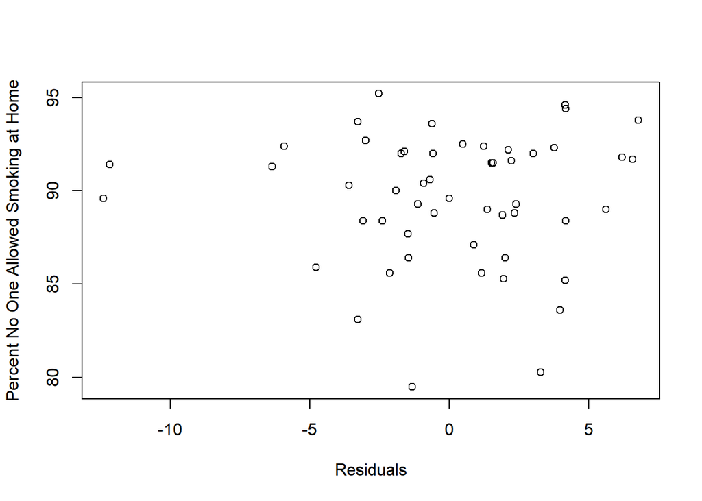

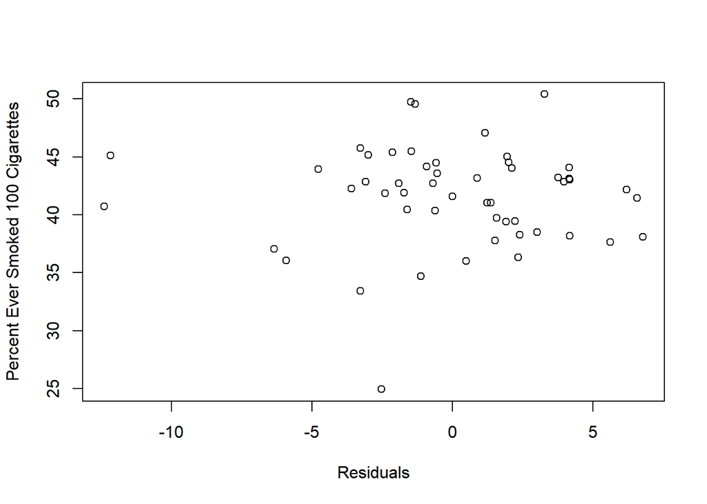

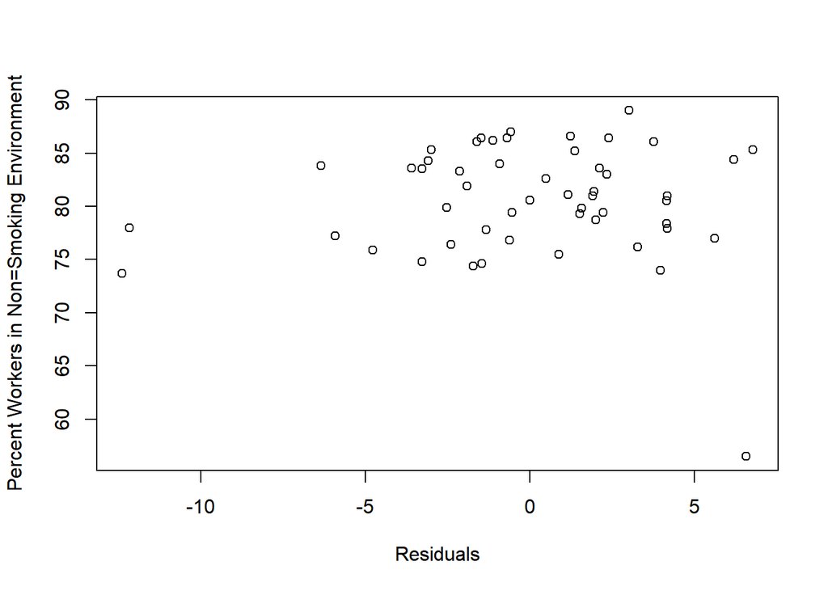

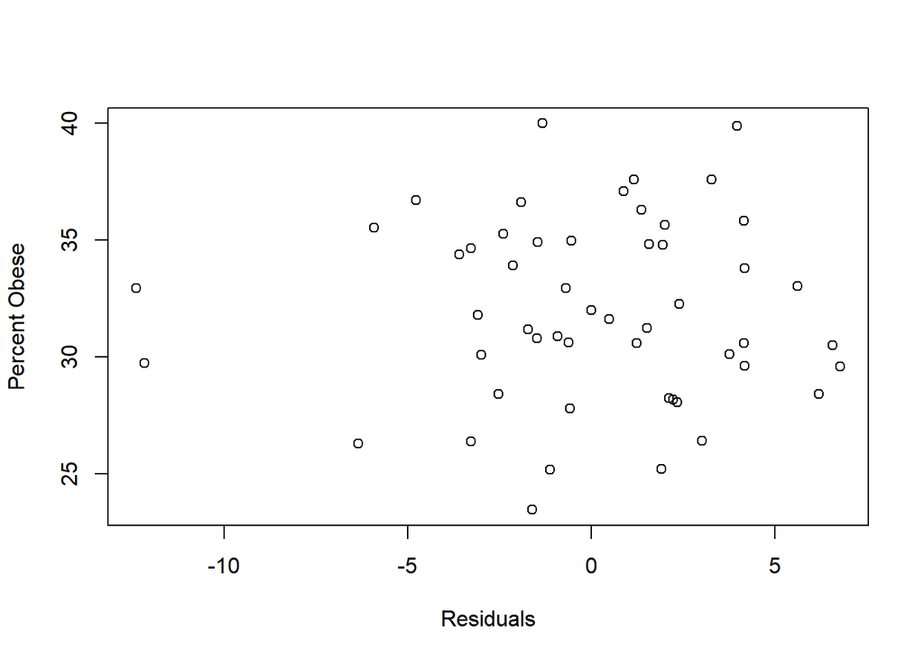

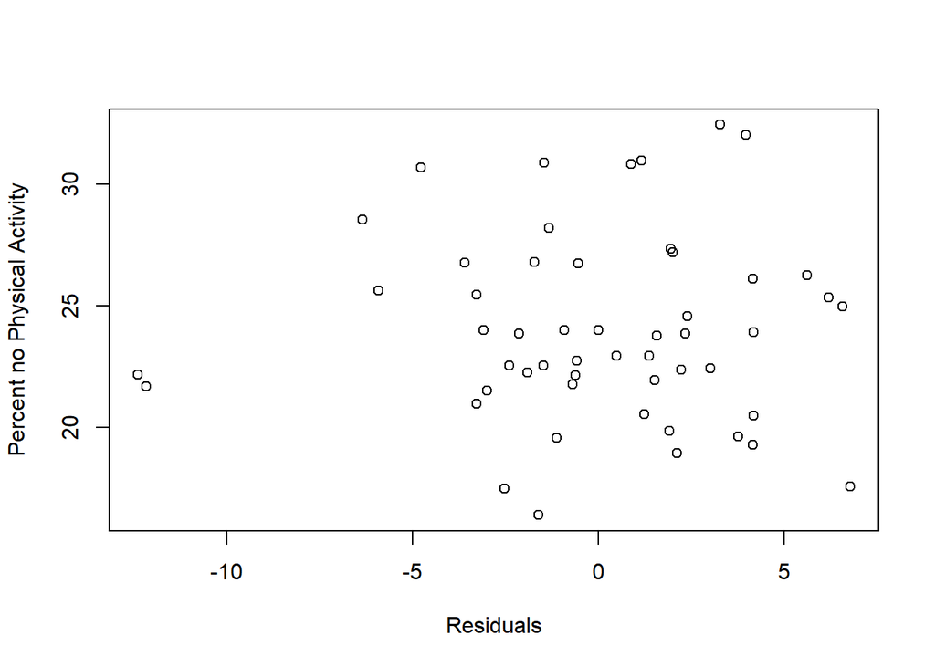

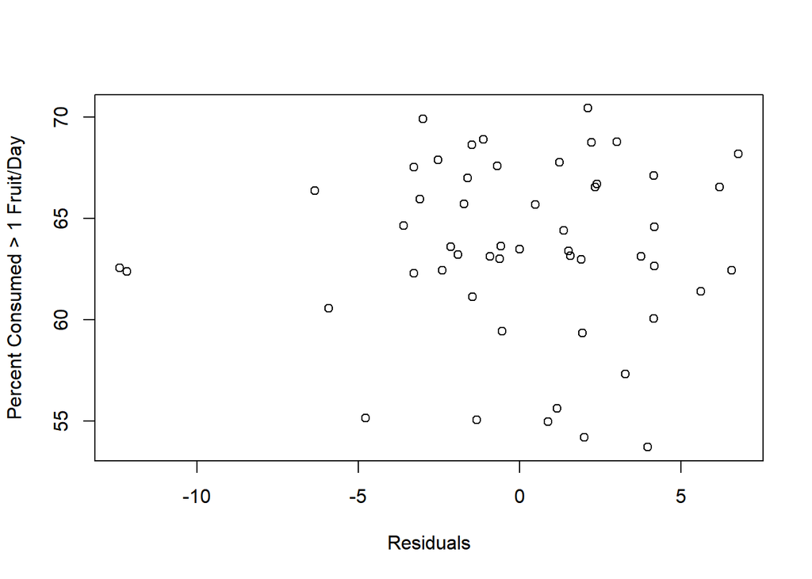

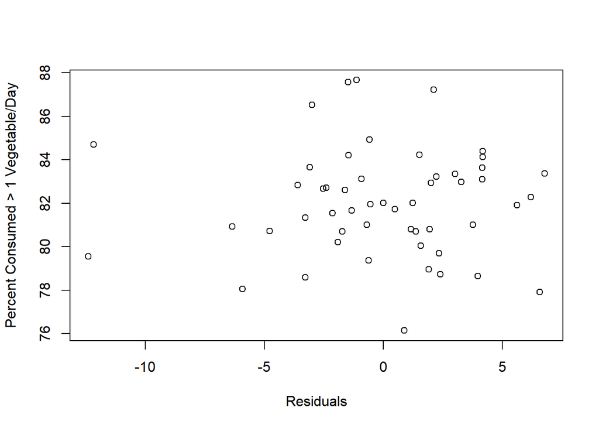

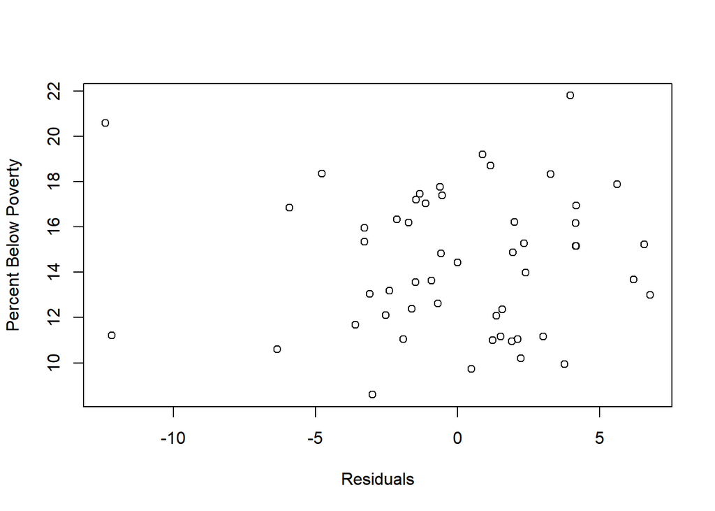

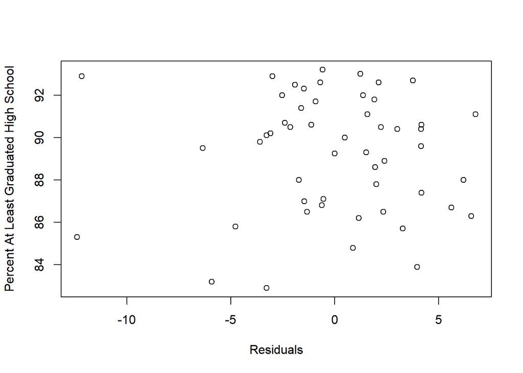

Examining Leverage Points / Influential Observations:

Throughout our Residual Analysis several data points were exposed as severe outliers. We wish to know whether these data points are highly influential and therefore interfering with the accuracy of our model. To do so we will first plot residuals against leverage, and Cook’s Distance vs observation. Cook’s Distance measures the influence a data point has by measuring its distance from the rest of the data.

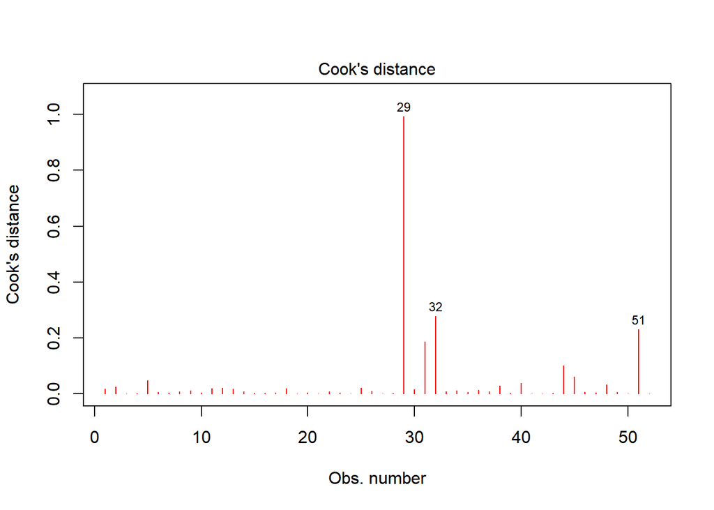

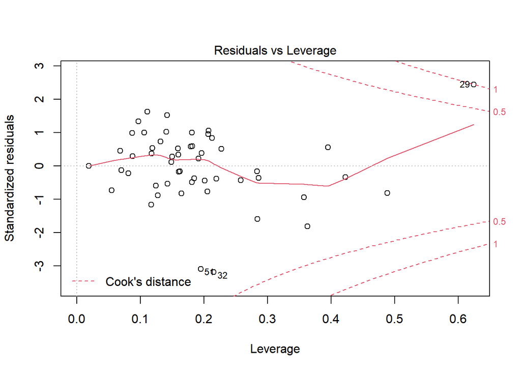

We can see that data point 29 (Nevada) has a Cook’s Distance value of approximately 1 which is considered to be influential. Data points 32 (New Mexico) and 51 (Wyoming) have smaller measures of approximately 0.2.For more clarity we will generate a Hat Matrix; a matrix that bears diagonal elements that represent the amount of leverage the corresponding data point in the data set has.

```r
#First Column (Intercept Column) of 1s
one=c(rep(1,52))

#matrix
x=matrix(c(one,Percent_No_One_Allowed_Smoking_at_Home,Percent_Ever_Smoked_100_Cigarettes,Percent_Workers_in_NonSmoking_Environment, Percent_Obese, Percent_No_Physical_Activity, Percent_Consumed_More_Than_1Fruit_PerDay, Percent_Consumed_More_Than_1Vegetable_PerDay, Percent_Below_Poverty, Percent_At_Least_Grad_Highschool),ncol= 10)


hat_matrix=x %*% solve(t(x) %*% x) %*% t(x)

#Looking for hat diagonals greater than 2p/n = 2*9/520 = 0.0346
inf_data =c()

for(i in 1:52){
  if(hat_matrix[i,i] > (2*9/52)){
    inf_data=append(inf_data,i)
  }
}

inf_data
```

```
## [1]  5  8 12 29 31 45
```

```r
print(c(hat_matrix[5,5],hat_matrix[8,8],hat_matrix[12,12],hat_matrix[29,29],hat_matrix[31,31],hat_matrix[45,45]))
```

```
## [1] 0.3573370 0.4229096 0.3949420 0.6244132 0.3627971 0.4886245
```

After conducting our analysis, we have a better understanding of the factors included and their effect on the incidence rate. One of the most interesting findings is that the variable “Current Percent Smoke” did not actually make it into our preferred model, rather, “percent ever smoked 100 cigarettes” was by far the most significant smoking factor increasing the incidence rate. This highlights the addictive and harmful properties of cigarettes as it may not just be the habitual smokers that are at risk. The most significant predictor in our model was “percent no physical activity”, it also had the largest coefficient which indicates it has the greatest impact due to the fact all of our predictors are scaled to percentages of population. It’s important to note that this analysis is done across all states, without specifying regional differences, differences in gender, or race, so these factors are nationally applicable and can therefore be used by anyone for bettering their understanding of lung and bronchus cancer risk, and adopting their behavior respectively.

Conclusion:

Most prominently in our favored model “selectedModel” but also common among all the models were several very significant variables: Percent Obese, Percent ever smoked 100 cigarettes, and percent no physical activity which had the highest coefficient in our favored model of 1.4321 indicating that a 1% increase in the population who partake in no physical activity would result in a 1.4321 increase in the incidence rate per 100,000. We ran into potential issues specifically with predictors in the dietary category (percent consumed more than 1 fruit/vegetable per day), having significant and positive effects on the cancer rate (increasing the rate) which runs contradictory to the latest cancer research that suggests increasing fruit and vegetable consumption would decrease the rate. However, after several tests for multicollinearity, sufficient residual analysis results, and model validation, we determined there was no significant enough presence of factors that would undermine the integrity of the model. It is important to note that further data collection would be useful for eliminating any possible interference that is having an effect on the dietary variable coefficients. Our model had an adjusted r-squared value of 0.8524 which we are confident in for any interpolation. As far as extrapolation, we would encourage further data collection before using the model for predictive purposes given the possibility of incorrect coefficient signs. Overall, the analysis performed supports the hypothesis that in order to decrease the incident rate of lung and bronchus cancer in the United States a focus on increasing exercise participation, promoting weight loss and/or weight gain prevention, and decrease smoking rates would be effective means to do so.